# Introduction

## A Few Words

[R](https://www.r-project.org/) has come a long way in its evolution. [Its download page](https://cran.r-project.org/) still looks the same as it was many years ago. Don’t be fooled by its archaic first look. They might have a particular way of honoring its history with the community that has provided tremendous support and turned this open-source software into one of the most popular data analytic tools today. The community is extremely supportive, and learning resources abound. That archaic look is not a sign of snobbishness, and I hope you come to like it. Welcome to the community.

In below, we assume you have [R](https://cran.r-project.org/) and [RStudio Desktop](https://www.rstudio.com/products/rstudio/download/) (free IDE) installed. It will be handy to have cheatsheets for [base R](http://github.com/rstudio/cheatsheets/raw/master/source/pdfs/base-r.pdf), [RStudio IDE](https://www.rstudio.com/wp-content/uploads/2016/01/rstudio-IDE-cheatsheet.pdf), [dplyr](https://github.com/rstudio/cheatsheets/raw/master/source/pdfs/data-transformation-cheatsheet.pdf), and [ggplot2](https://www.rstudio.com/wp-content/uploads/2016/11/ggplot2-cheatsheet-2.1.pdf). If you find this introduction too technical, please start with ([ModernDive](https://ismayc.github.io/moderndiver-book/4-viz.html) open-source textbook) (say, up to Chapter 5).

## Materials

R community makes progress every time a user distributes his or her work through a R package, or a bundle of user-developed programs. Recent developments such as [tidy](https://cran.r-project.org/web/packages/tidyr/vignettes/tidy-data.html), [dplyr](https://cran.r-project.org/web/packages/dplyr/vignettes/introduction.html), and [ggplot2](http://docs.ggplot2.org/current/) have streamlined much of coding for data manipulation and analysis, and it is a good place to start learning R. With this new syntax system, you will learn the components of data wrangling and visualization as *your data operation language*. Like any language, its framework can give you a particular way of understanding the world and influence your thinking.

Let’s start with a sample dataset of airplane departures and arrivals for the planes that departed from New York City in 2013 (source: [Bureau of Transportation Statistics](https://www.transtats.bts.gov/DatabaseInfo.asp?DB_ID=120&Link=0)). We load a built-in data frame by command `library(nycflights13)` where `library(package_name)` tells R to load a R package named “package_name” in the current R session (i.e., the computing environment). R packages are installed to your computer by `install.packages()` command as needed. In R (Rstudio) console, type `install.packages("nycflights13")` and hit enter.

To install a few more packages we use in below, copy the following code and execute it in your R console.

```r
required_pkgs <- c("nycflights13", "dplyr", "ggplot2", "lubridate", "knitr", "tidyr", "broom")
  # "c()" concatenates names here.
  # "<-" assigns what is on the right to left, which is a name for new vector here.

new_pkgs <- required_pkgs[!(required_pkgs  %in% installed.packages())]
  # "%in%" checks whether items on the left are in items on the right.

if (length(new_pkgs)) {
  install.packages(new_pkgs, repos = "http://cran.rstudio.com")
}   # "repos =" specifies which repository you download packages from.
```

where `#` is used to add comments that are helpful to humans but are ignored by R.

Each time we start a new session in R, we load libraries.

```r
suppressWarnings({
  suppressMessages({
    library(dplyr)  # for data manipulation
    library(ggplot2)  # for figures
    library(lubridate) # for date manipulation
    library(nycflights13)  # sample data of NYC flights
    library(knitr) # for table formatting
    library(tidyr) # for table formatting
    library(broom)  # for table formatting
  })
})
```

Now we can see the data.

```r
class(flights) # shows the class attribute
```

```
## [1] "tbl_df"     "tbl"        "data.frame"
```

```r
dim(flights)   # obtains dimention rows by columns
```

```
## [1] 336776     20
```

```r
head(flights)  # displays first seveal rows and columns
```

```
## # A tibble: 6 × 20
##    year month   day dep_time sched_dep_time dep_delay arr_time
##   <int> <int> <int>    <int>          <int>     <dbl>    <int>
## 1  2013     1     1      517            515         2      830
## 2  2013     1     1      533            529         4      850
## 3  2013     1     1      542            540         2      923
## 4  2013     1     1      544            545        -1     1004
## 5  2013     1     1      554            600        -6      812
## 6  2013     1     1      554            558        -4      740
## # ... with 13 more variables: sched_arr_time <int>, arr_delay <dbl>,
## #   carrier <fctr>, flight <int>, tailnum <chr>, origin <chr>, dest <chr>,
## #   air_time <dbl>, distance <dbl>, hour <dbl>, minute <dbl>,
## #   time_hour <dttm>, res <dbl>
```

`dim()` command returns the dimension (rows and columns) of `flights` data frame, and `head()` command returns the first several rows and columns of the data frame. We see that the data frame contains information on dates, scheduled and actual departures and arrivals, carriers, origins, destinations, travel times, and distances. These variables are arranged in columns, and each row represents an observation of values for the variables. The term “data frame” refers to a *class* in R that is a general version of matrix that can contain more than one mode (numeric, character, factor etc) and have more attributes. (In case you are curious, here is an overview of data [types](http://www.statmethods.net/input/datatypes.html) and [dates](http://www.statmethods.net/input/dates.html).)

## Carfts & Arts

### Crafts

Let’s look at the six types of data wrangling functions in the `dplyr` package.

- `filter()`: subsets rows (e.g. observations) in a data frame. We put in logical vector(s).
- `select()`: subsets columns (e.g. variables) in a data frame. We put in column name(s).
- `arrange()`: orders rows in a data frame. We put in column names(s).
- `summarise()`: collapses a data frame into a row(s) of summary statistics. We put in **summary functions** (e.g. statistics functions) using column names.
- `mutate()`: creates a new variable(s) and adds it to the existing columns. We put in **window functions** (e.g. transforming operations) using column names.
- `group_by()`: assigns rows into groups in a data frame. We put in column name(s).

The first argument in all these functions is *a data frame*, and by knowing this we can easily *pipe* a sequence of data operations through `%>%` operator. For example, we want to find average delays in departures and arrivals from New York to St. Paul-Minneapolis airport (MSP). We can take the flight data frame, apply `filter()` to subset rows into the flights to MSP, and then apply `summarise()` to calculate the mean statistics. Note that this involves a sequence of data operations, and one can translate it into codes by inserting `%>%` operator that reads as *then*.

```r
flights %>%  # take the flights data frame, then
  filter(dest == "MSP") %>%  # filter rows, then
  summarise(
    # summarise departure and arrival delays into their means and call them mean_dep_delay and mean_arr_delay
    mean_dep_delay = mean(dep_delay, na.rm = TRUE),
    mean_arr_delay = mean(arr_delay, na.rm = TRUE)
    )    # calculate the mean, while removing NA values
```

```
## # A tibble: 1 × 2
##   mean_dep_delay mean_arr_delay
##            <dbl>          <dbl>
## 1       13.32481       7.270169
```

The `=` symbol in the `summarise()` function is used as a column name assignment for the summarized data, and the two arguments inside `summarise()` are parallel operations, which in this case are the mean function applied to different variables. In `summarise()`, one can use **summary functions** that takes a vector and outputs a single value.

Each time we apply `%>%` operator above, we pass a modified data frame from one data operation to another through the first argument. This code is equivalent to

[output not shown]

You will quickly learn that `%>%` operator makes the code much easier to read, write, and edit and why that is so important.

Let’s add a few more lines to the above example. Say, we want to see the average delays by carrier and sort the results by the number of observations (e.g. flights) in descending order.

```r
flight_stats_MSP <- flights %>%  # assign the results in an object named "flight_stats"
  filter(dest == "MSP") %>%
  group_by(carrier) %>%  #  group rows by carrier
  summarise(
    n_obs = n(),  # count number of rows
    mean_dep_delay = mean(dep_delay, na.rm = TRUE),
    mean_arr_delay = mean(arr_delay, na.rm = TRUE)
  ) %>%
  arrange(desc(n_obs))  # sort by n_obs in descending order

flight_stats_MSP  # show flight_stats object
```

```
## # A tibble: 6 × 4
##   carrier n_obs mean_dep_delay mean_arr_delay
##    <fctr> <int>          <dbl>          <dbl>
## 1      DL  2864      10.651392       4.035702
## 2      EV  1773      17.093413      10.527995
## 3      MQ  1293       8.255457       9.559350
## 4      9E  1249      19.658113       8.089776
## 5      OO     4       0.750000      -2.000000
## 6      UA     2      -6.000000      -5.500000
```

Carrier variable is expressed in International Air Transportation Association (IATA) code, so let’s add a column by joining a data frame called “airlines” that contains information on IATA codes and airline names. In Rstudio, you can find the airlines data frame under **Environment** tab (in the upper right corner) by switching the display option from *Global Environment* to *package:nycflights13*. To inspect the data frame, type `View(airlines)` in the R console (in the left bottom corner). Also, more generally, type `data()` in the console to see a list of all datasets that are loaded with libraries.

```r
left_join(flight_stats_MSP, airlines, by="carrier") %>%
  # left_join(a,b, by="var") means joining matching rows from b to a by identifier named "var".
  kable(digits=2)  # prints a better-looking table
```

| carrier | n_obs | mean_dep_delay | mean_arr_delay | name |
| --- | --- | --- | --- | --- |
| DL | 2864 | 10.65 | 4.04 | Delta Air Lines Inc. |
| EV | 1773 | 17.09 | 10.53 | ExpressJet Airlines Inc. |
| MQ | 1293 | 8.26 | 9.56 | Envoy Air |
| 9E | 1249 | 19.66 | 8.09 | Endeavor Air Inc. |
| OO | 4 | 0.75 | -2.00 | SkyWest Airlines Inc. |
| UA | 2 | -6.00 | -5.50 | United Air Lines Inc. |

Let’s consider an example of adding new variables using `mutate()`.

```r
flights %>%
  select(dep_delay, arr_delay, air_time) %>%
    # keep only columns named "dep_delay", "arr_delay", and "air_time"
  mutate(
    gain = arr_delay - dep_delay,
    gain_per_hr = gain / (air_time / 60)
      # Note: we can refer to "gain" variable as we define.
  )
```

```
## # A tibble: 336,776 × 5
##    dep_delay arr_delay air_time  gain gain_per_hr
##        <dbl>     <dbl>    <dbl> <dbl>       <dbl>
## 1          2        11      227     9    2.378855
## 2          4        20      227    16    4.229075
## 3          2        33      160    31   11.625000
## 4         -1       -18      183   -17   -5.573770
## 5         -6       -25      116   -19   -9.827586
## 6         -4        12      150    16    6.400000
## 7         -5        19      158    24    9.113924
## 8         -3       -14       53   -11  -12.452830
## 9         -3        -8      140    -5   -2.142857
## 10        -2         8      138    10    4.347826
## # ... with 336,766 more rows
```

Note that by using `select()`, the data frame now contains only the selected columns “dep_delay”, “arr_delay”, and “air_time” and the new columns defined by **window functions** in `mutate()`. The five types of [window functions](https://cran.r-project.org/web/packages/dplyr/vignettes/window-functions.html) are (1) recycled summary values which are interpreted as a vector of repeated values (any **summary function**): (2) of ranking or ordering type (`row_number()`, `min_rank()`, `dense_rank()`, `cume_dist()`,`percent_rank()`, and `ntile()`): (3) of offset type, say defining a lagged variable in time series data (`lead()` and `lag()`): (4) cumulative aggregates (`cumsum()`, `cummin()`, `cummax()`, `cumall()`, `cumany()`, and `cummean()`): (5) fixed-window rolling aggregates such as windowed mean, median, etc. (see [RcppRoll](https://cran.r-project.org/web/packages/RcppRoll/index.html) package). You can find a help file for any function, for example, by typing `?cumsum`. Knowing what functions are available is useful.

We can also define custom functions and use them in `dplyr`-style data manipulations. A function takes some arguments and returns an output (Note: a list is used for returning multiple outputs). Arguments are separated by comma `","` and matched either by locations or equated object names with `"="` sign. The user needs to enter all the arguments of a function except for those that have specified default values. Let’s go through a few examples.

```r
# generate a sequence from 1 to 10 (by the increment of 1) and name it  "vec1".
# adding "()"" while making an assignment "<-" means to print the new object.
(vec1 <- 1:10)
```

```
##  [1]  1  2  3  4  5  6  7  8  9 10
```

```r
(vec2 <- c(vec1, NA, NA))
```

```
##  [1]  1  2  3  4  5  6  7  8  9 10 NA NA
```

```r
my_mean_1 <- function(x)  mean(x, na.rm = TRUE)
  # This function takes one argument: x and returns the calculation result of mean(x, na.rm = TRUE).
  # x is required (and implicitly assumed to be a vector of numeric values).
  # mean() is an existing function. The "na.rm" argument of mean() is set to be TRUE.
  # Note: this function is defined in one expression (R's execution). Multiple executions are combined with "{ }".

my_mean_1(vec1)
```

```
## [1] 5.5
```

```r
my_mean_2 <- function(x, na.rm=TRUE)  mean(x, na.rm = na.rm)
  # Input arguments: x and na.rm (optional with the default value of TRUE)
  # Output: the calculation result of mean(x, na.rm = na.rm).
  # The "na.rm" argument of mean() is provided as the "na.rm" argument of my_mean_2().

my_mean_2(vec2)
```

```
## [1] 5.5
```

```r
my_mean_2(vec2, na.rm=FALSE)  # not revmoving NA returns NA for the mean calculation.
```

```
## [1] NA
```

```r
my_zscore <- function(x, remove_na=TRUE) {
  # blanketing with { } makes a long expression more legible.
  (x - my_mean_2(x, na.rm = remove_na))/sd(x, na.rm = remove_na)
}
  # Inputs: x and remove_na (optional: default = TRUE)
  # Output: z-score of vector x
  # Note: this function uses a recycling rule of R.
  # my_mean() and sd() are scalers but are interpreted as a vector of repeated valuses with the length of x.

my_zscore(vec1) %>% round(2)
```

```
##  [1] -1.49 -1.16 -0.83 -0.50 -0.17  0.17  0.50  0.83  1.16  1.49
```

```r
my_dow <- function(date) {
  dow <- as.POSIXlt(date)[['wday']] + 1
  # as.POSIXlt(date)[['wday']] returns integers 0, 1, 2, .. 6, for Sun, Mon, ... Sat.
  # Here we extract one item from a vector (Sun, Mon, ..., Sat) by position numbered between 1 to 7.
  c("Sun", "Mon", "Tue", "Wed", "Thu", "Fri", "Sat")[dow]  # extract "dow"-th element
}
  # Input: date in the format of  "2017-01-23"
  # Output: day of week
Sys.Date()  # Sys.Date() returns the date
```

```
## [1] "2017-03-29"
```

```r
my_dow(Sys.Date())
```

```
## [1] "Wed"
```

Let’s apply these `my_mean_2()` and `my_zscore()` functions inside `summarise()` and `mutate()`.

```r
flights %>%
  select(dep_delay) %>%
  summarise(
    mean_dep_delay = my_mean_2(dep_delay),  # using my_mean_2()
    mean_dep_delay_na = my_mean_2(dep_delay, na.rm = FALSE)  # this returns NA
  ) %>%
  kable(digits=2)
```

| mean_dep_delay | mean_dep_delay_na |
| --- | --- |
| 12.64 | NA |

```r
flights_gain <- flights %>%
  ungroup() %>%
  select(dep_delay, arr_delay, air_time) %>%
  mutate(
    gain = arr_delay - dep_delay,
    gain_per_hr = gain / (air_time / 60),
    gain_z = (gain - my_mean_2(gain))/sd(gain, na.rm=TRUE),  # using my_mean_2()
    gain_per_hr_z = my_zscore(gain_per_hr)  # using my_zscore()
  )

head(flights_gain) %>%
  kable(digits=2)
```

| dep_delay | arr_delay | air_time | gain | gain_per_hr | gain_z | gain_per_hr_z |
| --- | --- | --- | --- | --- | --- | --- |
| 2 | 11 | 227 | 9 | 2.38 | 0.81 | 0.50 |
| 4 | 20 | 227 | 16 | 4.23 | 1.20 | 0.67 |
| 2 | 33 | 160 | 31 | 11.62 | 2.03 | 1.33 |
| -1 | -18 | 183 | -17 | -5.57 | -0.63 | -0.21 |
| -6 | -25 | 116 | -19 | -9.83 | -0.74 | -0.59 |
| -4 | 12 | 150 | 16 | 6.40 | 1.20 | 0.86 |

The `dplyr` package also contains `summarise_each()` function that can be used to apply standard **summary functions** to each column of variables. This is easy to use when there is only single argument, say `mean(vec1)`. Passing through multiple arguments, say `mean(vec2, na.rm=TRUE)`, involves some complication with syntax. Let’s first try removing rows that contain missing (NA) values and then apply `summarise_each()`. The concatenated function name indicates which function is used to generate the summary.

```r
flights_gain %>%
  select(-contains("_z"))  %>%
    # deselect variables whose names contain "_z" using "-" sign in front.
  filter(!is.na(dep_delay) & !is.na(arr_delay)) %>%
    # filter out rows that have NA values in dep_delay or arr_deplay
  summarise_each(c("mean", "sd")) %>%
    # summarise_each(func_names) applies functions named func_names to each column.
  round(digits=2)
```

```
## # A tibble: 1 × 10
##   dep_delay_mean arr_delay_mean air_time_mean gain_mean gain_per_hr_mean
##            <dbl>          <dbl>         <dbl>     <dbl>            <dbl>
## 1          12.56            6.9        150.69     -5.66            -3.26
## # ... with 5 more variables: dep_delay_sd <dbl>, arr_delay_sd <dbl>,
## #   air_time_sd <dbl>, gain_sd <dbl>, gain_per_hr_sd <dbl>
```

The method for passing multiple arguments or using custom summary functions is to use a list generated by `funs()`.

```r
my_mean_fun <- funs(m1 = my_mean_2, m2 = "my_mean_2", m3 = my_mean_2(., na.rm=TRUE))
  # funs() generates a list of functions calls that can be passed through summarise_each(): see ?funs
  # m1: function object e.g. my_mean_2
  # m2: function name  e.g. "my_mean_2"
  # m3: function call with . parameter  e.g. my_mean_2(., na.rm=TRUE)

flights_gain %>%
  select(-contains("_z")) %>%
  summarise_each(my_mean_fun) %>%
    round(digits=2)
```

```
## # A tibble: 1 × 15
##   dep_delay_m1 arr_delay_m1 air_time_m1 gain_m1 gain_per_hr_m1
##          <dbl>        <dbl>       <dbl>   <dbl>          <dbl>
## 1        12.64          6.9      150.69   -5.66          -3.26
## # ... with 10 more variables: dep_delay_m2 <dbl>, arr_delay_m2 <dbl>,
## #   air_time_m2 <dbl>, gain_m2 <dbl>, gain_per_hr_m2 <dbl>,
## #   dep_delay_m3 <dbl>, arr_delay_m3 <dbl>, air_time_m3 <dbl>,
## #   gain_m3 <dbl>, gain_per_hr_m3 <dbl>
```

### Arts

Now let’s cover the basics of data visualization using [ggplot2](http://docs.ggplot2.org/current/) package. There are three essential components to graphics in the `ggplot2` syntax: **data**, **aes**, and **geom** ([ModernDive](https://ismayc.github.io/moderndiver-book/4-viz.html) open-source textbook). This implements a philosophy stated as follows;

> A statistical graphic is a mapping of **data** variables to **aesthetic** attributes of **geometric** objects.  
> — Wilkinson (2005)

While coding complex graphics via `ggplot()` may appear intimidating at first, they boil down to the three primary components:

- **data**: a data frame e.g. the first argument in `ggplot(data, ...)`.
- **aes**: specifications for x-y, color, shape, and size. e.g. `aes(x = var_x, y = var_y, shape = var_z)`
- **geom**: geometric objects such as points, lines, bars, etc. e.g. `geom_point()`, `geom_line()`, `geom_histogram()`

Since R offers great flexibility with graphics, one can further combine secondary components such as:

- stat: data transformation, overlay of statistical inferences etc.
- scales: scaling data points etc.
- coord: Cartesian coordinates, polar coordinates, mapping projections etc.
- facet: laying out multiple plot panels in a grid etc.

and more. Following [ModernDive](https://ismayc.github.io/moderndiver-book/4-viz.html), let’s go over five basic types of plots: scatter-plots, line-graphs, boxplots, histograms, and barplots.

Let’s start with **barplots** by examining whether there is any obvious pattern of flight distribution across airport origins in New York. A barplot shows counts by category, a simple visualization.

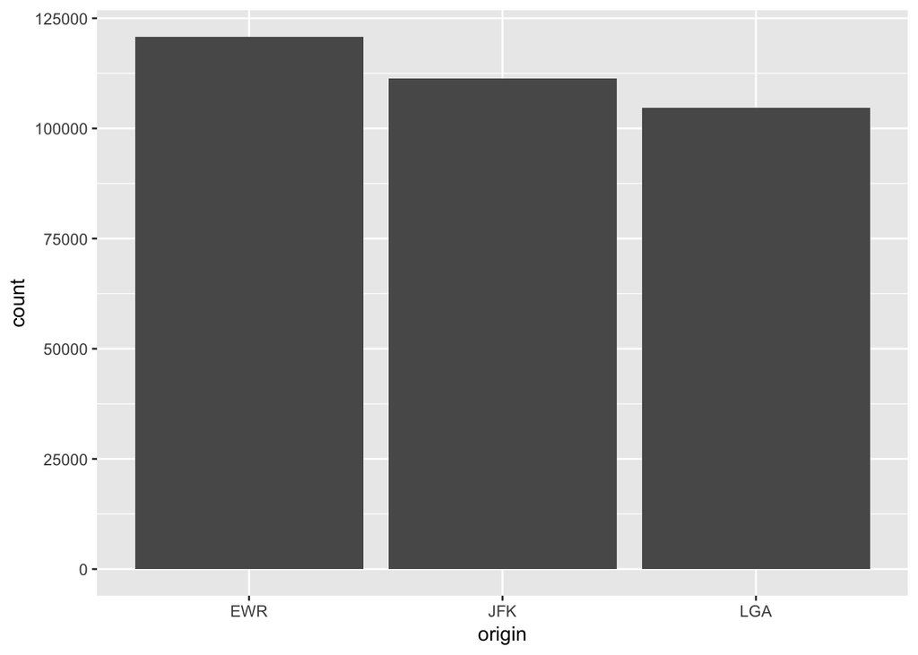

```r
ggplot(data = flights,  # the first argument is the data frame
       mapping = aes(x = origin)) +   # the second argument is "mapping", which is aes()
  geom_bar()  #  after "+" piping operator of ggplot(), we add geom_XXX() elements
```

We can make this more informative and aesthetic.

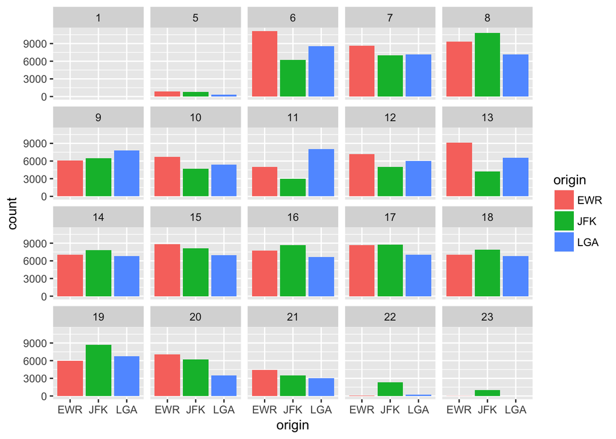

```r
ggplot(data = flights,
       mapping = aes(x = origin, fill = origin)) +  # here "fill" gives bars distinct colors
  geom_bar() +
  facet_wrap( ~ hour)  #  "facet_wrap( ~ var)" generates a grid of plots for each value of var
```

Another way to see the same information is a **histogram**.

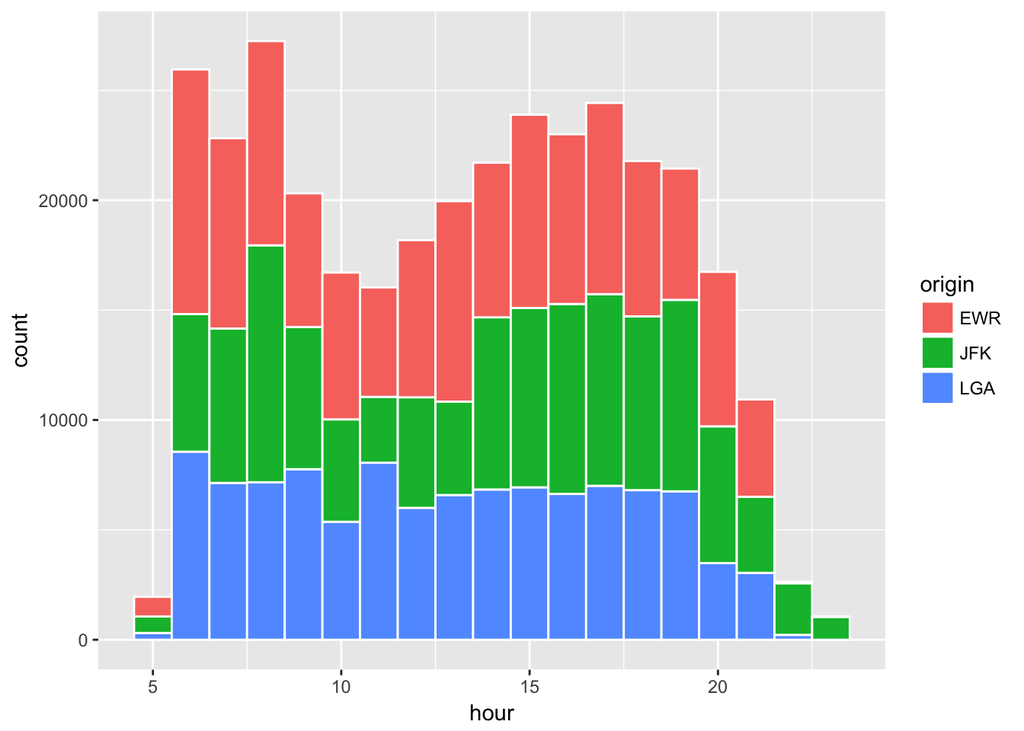

```r
flights %>%
  filter(hour >= 5) %>%  # exclude hour earlier than 5 a.m.
  ggplot(aes(x = hour, fill = origin )) + geom_histogram(binwidth = 1, color = "white")
```

Mornings and late afternoons get busy, but there is not much difference across flight origins. Is there a pattern throughout the year? Let’s take the average of departure delays for each day by flight origin and plot as a time series.

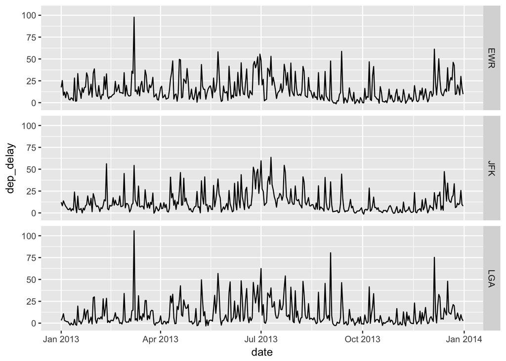

```r
delay_day <- flights %>%
  group_by(origin, year, month, day) %>%
  summarise(dep_delay = mean(dep_delay, na.rm = TRUE))  %>%
  mutate(date = as.Date(paste(year, month, day), format="%Y %m %d")) %>%
  filter(!is.na(dep_delay))  #  exclude rows with dep_delay == NA

delay_day %>%     # "facet_grid( var ~ .)" is similar to "facet_wrap( ~ var)"
  ggplot(aes(x = date, y = dep_delay)) + geom_line() + facet_grid( origin ~ . )
```

Are the three series correlated? Let’s look at a few months more closely.

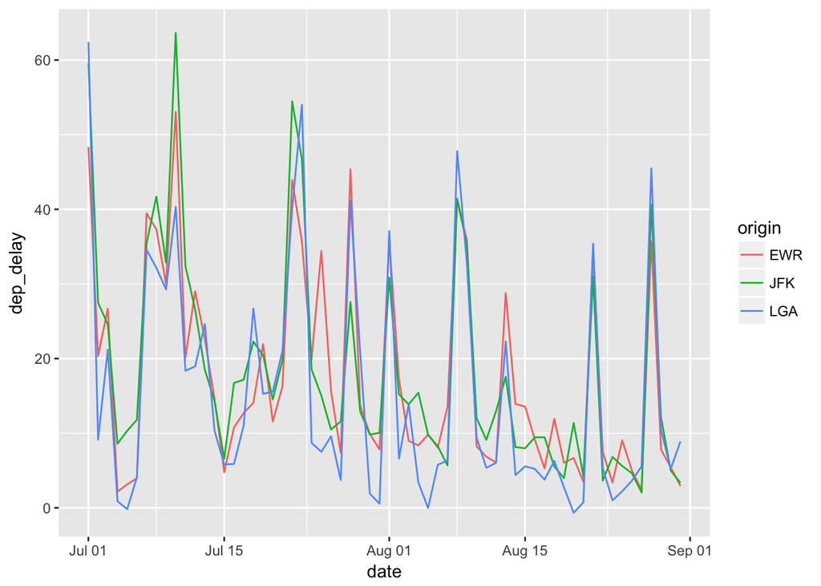

```r
delay_day %>%
  filter("2013-07-01" <= date, "2013-08-31" >= date)  %>%
  ggplot(aes(x = date, y = dep_delay, color = origin)) + geom_line()
```

We see similar patterns of speakes and troughs occuring on certain days. Is the pattern cyclical? Let’s compare by day of the week.

```r
delay_day <- flights %>%
  group_by(year, month, day) %>%
  summarise(dep_delay = mean(dep_delay, na.rm = TRUE))  %>%
  mutate(date = as.Date(paste(year, month, day), format="%Y %m %d"),  # date defined by as.Data() function
         wday = my_dow(date),
         weekend = wday %in% c("Sat", "Sun")  #  %in% operator: A %in% B checks whether each element of A is in B.
  )

delay_day$wday[1:20] %>% print()
```

```
##  [1] "Tue" "Wed" "Thu" "Fri" "Sat" "Sun" "Mon" "Tue" "Wed" "Thu" "Fri"
## [12] "Sat" "Sun" "Mon" "Tue" "Wed" "Thu" "Fri" "Sat" "Sun"
```

```r
delay_day$wday <- factor(delay_day$wday,
                         levels = c("Mon", "Tue", "Wed", "Thu", "Fri", "Sat", "Sun"))
                            # adding labels and rearranging the order starting on Mon
delay_day$wday[1:20] %>% print()
```

```
##  [1] Tue Wed Thu Fri Sat Sun Mon Tue Wed Thu Fri Sat Sun Mon Tue Wed Thu
## [18] Fri Sat Sun
## Levels: Mon Tue Wed Thu Fri Sat Sun
```

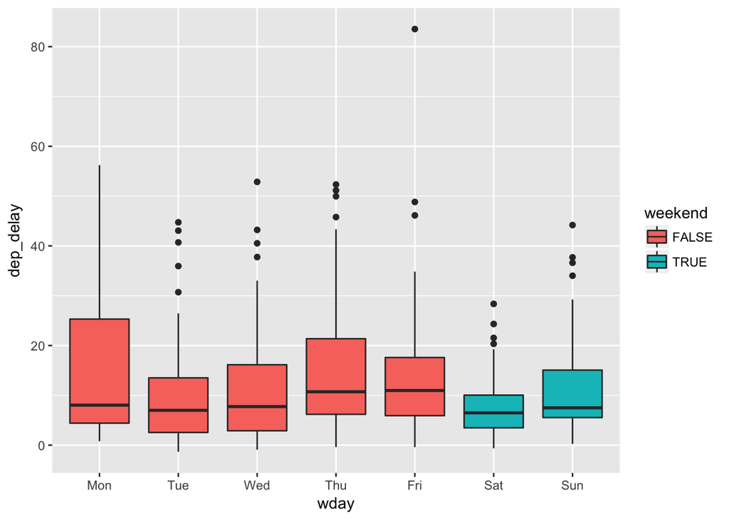

```r
delay_day  %>%
  filter(!is.na(dep_delay)) %>%
  ggplot(aes(x = wday, y = dep_delay, fill = weekend)) + geom_boxplot()
```

It appears that average delays are longer on Thursdays and Fridays and shorter on Saturdays.

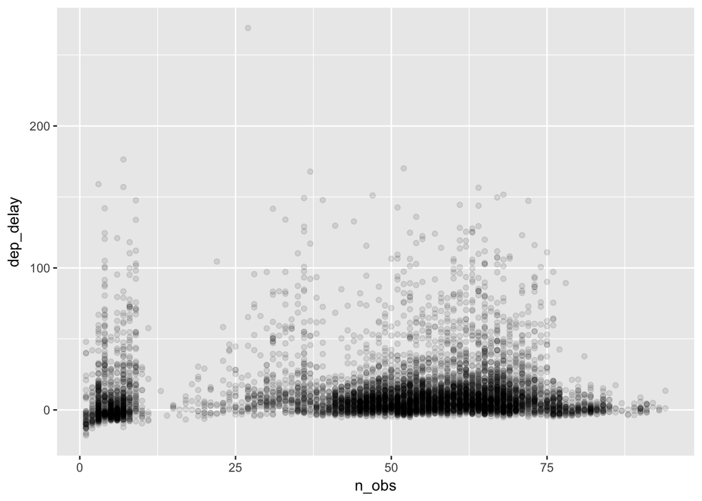

```r
delay_day_hr <- flights %>%
  group_by(year, month, day, hour) %>%  # Note: "hour" is added here
  summarise(
    n_obs = n(),
    dep_delay = mean(dep_delay, na.rm = TRUE),
    arr_delay = mean(arr_delay, na.rm = TRUE)
    # gain = mean(arr_delay - dep_delay, na.rm = TRUE),
    # dist = mean(distance, na.rm = TRUE)
  )  %>%
  mutate(date = as.Date(paste(year, month, day), format="%Y %m %d"),
         wday = c("Sun", "Mon", "Tue", "Wed", "Thu", "Fri", "Sat")[as.POSIXlt(date)[['wday']] + 1]
  )

plot_delay <- delay_day_hr  %>% filter(!is.na(dep_delay)) %>%
  ggplot(aes(x = n_obs, y = dep_delay)) + geom_point(alpha = 0.1)
    # plot of n_obs and the average dep_delay by date-hour

plot_delay
```

The plot shows that by the density of data points along the horizontal axis, the number of flights is not evenly distributed across all date-hours. That is, some days are businer than others, and some hours are busiers than others. The distribution of `n_obs` has two peaks, showing that there are very slow days or hours at the airports (e.g. less than 10 flights flying out of New York city in hour). We might guess that the delays in the slow days or hours be caused by bad weather in New York (or in other cities to an extent). On the other hand, we may wonder if the excess delays in peak hours, compared to slow hours, are caused by congestion at the airports. Let’s find out by fitting curves that trace out the relationships between `n_obs` and `dep_delay`.

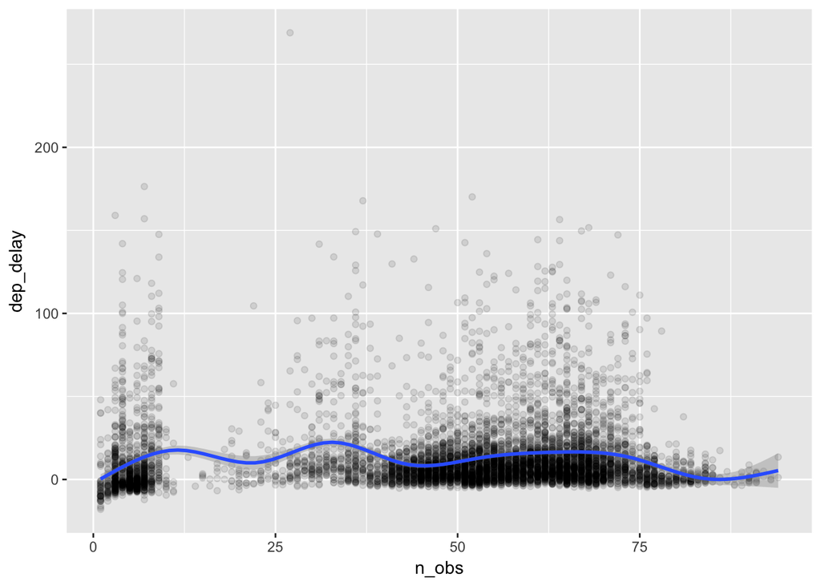

```r
plot_delay  +
  geom_smooth()   #  geom_smooth() addes a layer of fitted curve(s)
```

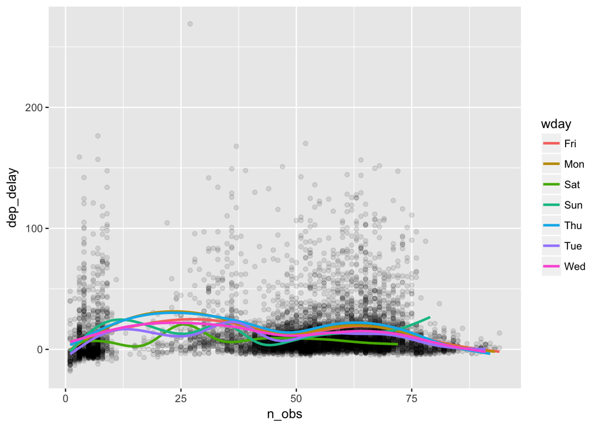

```r
plot_delay  +
     # additional aes() argument for applying different colors to the day of the week
  geom_smooth(aes(color = wday), se=FALSE)
```

Surprisingly, `dep_delay` do not change over the range of `n_obs`, including the peak hours. There are more dealys on Thursdays and Fridays and less delays on Saturdays, but we see no evidence of congestion as a cause of delay.

Let’s take a closer look at the distribution of departure delays. If it is not normal, we may want to apply a transformation.

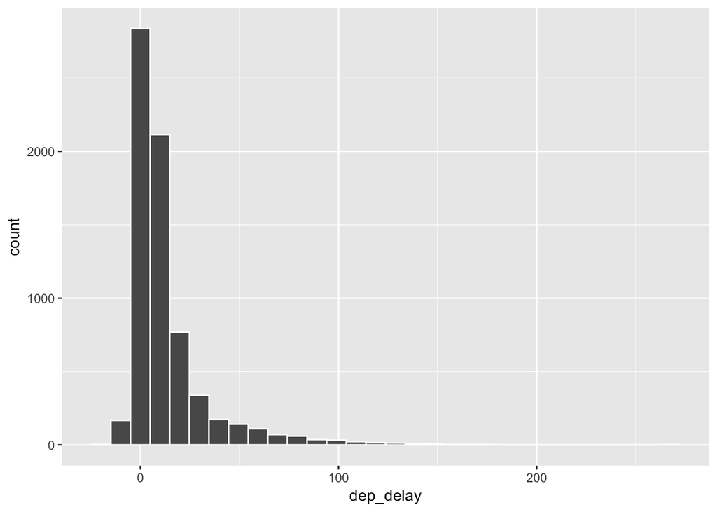

```r
delay_day_hr %>%  filter(!is.na(dep_delay)) %>%
  ggplot(aes(x = dep_delay)) + geom_histogram(color = "white") # Note: the distribution is skewed
```

```r
delay_day_hr$dep_delay_shifted <- delay_day_hr %>% with(dep_delay - min(dep_delay, na.rm = TRUE) + 1)
    # with() function: it takes a data frame in the first argument and allows one to use variable names inside the data frame
    # Before we apply a logarithmic transformation, we shift the variable so that its minimum is greater than zero.

delay_day_hr %>%
  ungroup() %>%   # removing group_by() attribute
  select(dep_delay, dep_delay_shifted) %>%
  with(
    apply(., 2, summary)
    # apply(data, num, fun)  applies function "fun" for each item of dimention "num" (1 = cows, 2= columns) of the data frame
    # In apply(), data comes from with() function and contains two selected variables.
    # These variables are referened by "." (all variables)
    )
```

```
##         dep_delay dep_delay_shifted
## Min.      -18.000              1.00
## 1st Qu.     1.054             20.05
## Median      6.571             25.57
## Mean       12.990             31.99
## 3rd Qu.    15.440             34.44
## Max.      269.000            288.00
## NA's       13.000             13.00
```

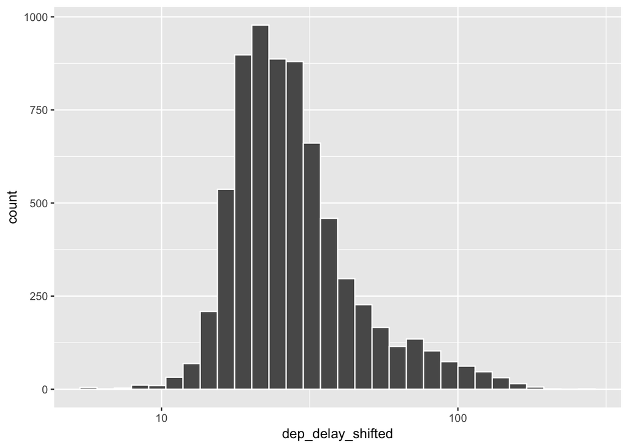

```r
delay_day_hr %>% filter(!is.na(dep_delay_shifted), dep_delay_shifted > 5) %>%
  ggplot(aes(x = dep_delay_shifted))  +
  scale_x_log10() +
    # Under the log of 10 transformation, the distribution looks closer to a normal distribution.
  geom_histogram(color = "white")
```

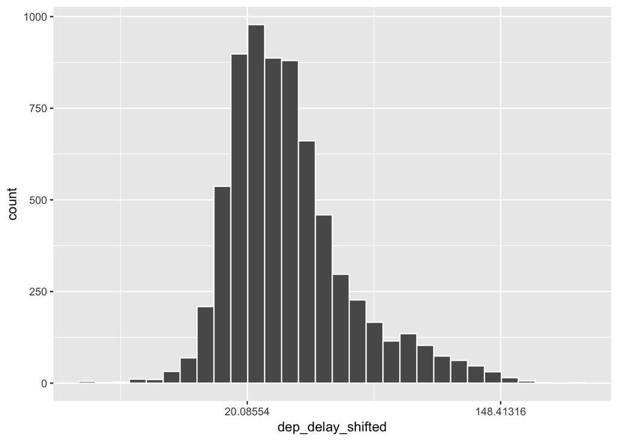

```r
delay_day_hr %>% filter(!is.na(dep_delay_shifted), dep_delay_shifted > 5) %>%
  ggplot(aes(x = dep_delay_shifted)) +
  scale_x_continuous(trans = "log") +
    # Alternatively, one can apply the natural logarithm to transform a variable. Histogram shows no difference here.
  geom_histogram(color = "white")
```

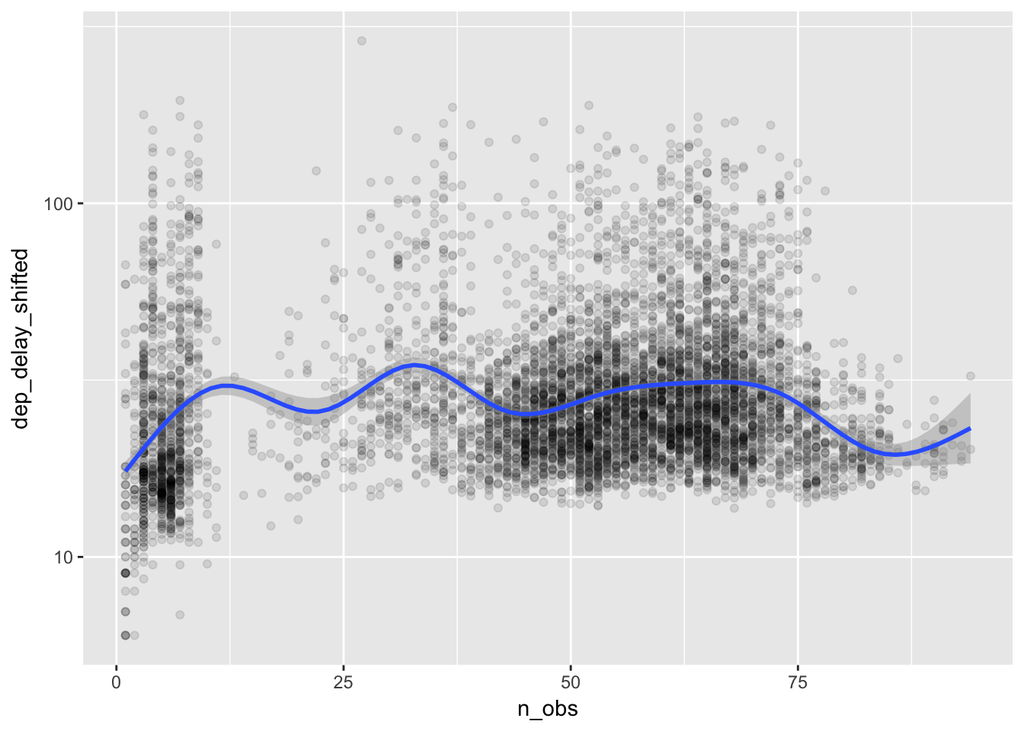

```r
delay_day_hr  %>% filter(!is.na(dep_delay_shifted), dep_delay_shifted > 5) %>%
  ggplot(aes(x = n_obs, y = dep_delay_shifted)) +
  scale_y_log10() +
   # With the transformation scale_y_log10(),  geom_point() and geom_smooth() are plotted.
  geom_point(alpha = 0.1)  +
  geom_smooth()
```

Under the logarithmic transformation, we still see no evidence that busy hours have more delays than slow hours. This appears to suggest that the airports in New York City manage fluctuating numbers of flights very well without causing congestion.

## Huning down numbers

If not airports, are airlines to blame for the delays? Previously, we saw that some airlines have higher mean delays than others for the case of NYC-MSP flights. Let’s look at the overall averages by carrier.

```r
stat_carrier <- flights %>%
  group_by(carrier) %>%
  summarise(n_obs = n(),
            dep_delay = mean(dep_delay, na.rm = TRUE),
            arr_delay = mean(arr_delay, na.rm = TRUE)
            ) %>%
  left_join(airlines, by="carrier") %>%
  arrange(desc(n_obs))
stat_carrier %>% kable(digit=2)
```

| carrier | n_obs | dep_delay | arr_delay | name |
| --- | --- | --- | --- | --- |
| UA | 58665 | 12.11 | 3.56 | United Air Lines Inc. |
| B6 | 54635 | 13.02 | 9.46 | JetBlue Airways |
| EV | 54173 | 19.96 | 15.80 | ExpressJet Airlines Inc. |
| DL | 48110 | 9.26 | 1.64 | Delta Air Lines Inc. |
| AA | 32729 | 8.59 | 0.36 | American Airlines Inc. |
| MQ | 26397 | 10.55 | 10.77 | Envoy Air |
| US | 20536 | 3.78 | 2.13 | US Airways Inc. |
| 9E | 18460 | 16.73 | 7.38 | Endeavor Air Inc. |
| WN | 12275 | 17.71 | 9.65 | Southwest Airlines Co. |
| VX | 5162 | 12.87 | 1.76 | Virgin America |
| FL | 3260 | 18.73 | 20.12 | AirTran Airways Corporation |
| AS | 714 | 5.80 | -9.93 | Alaska Airlines Inc. |
| F9 | 685 | 20.22 | 21.92 | Frontier Airlines Inc. |
| YV | 601 | 19.00 | 15.56 | Mesa Airlines Inc. |
| HA | 342 | 4.90 | -6.92 | Hawaiian Airlines Inc. |
| OO | 32 | 12.59 | 11.93 | SkyWest Airlines Inc. |

There seems to be some differences. However, we need to remember that our dataset covers only the flights from New York City, which may not be representative of all hub airprots across the United States. The table shows simple averages of delays across various routes, days, and hours of flights that may systematically differ across carriers, who use differenet airports around the country as their hubs. Moreover, the concept of “delay” is complicated because it is with reference to the scheduled depature and arrival times, which may differ by carrier (e.g., think of the time sitting in the airplane before taking off and after landing).

For our purposes, lets see whether the average air time differs across carriers by accounting for flight’s destinatination and timing.  
(It would be more interesting to use schduled flight duration from depature to arrival for each flight instead of air time, but the calculation is complicated with our data.) Let’s first check how air time relates to flight distance.

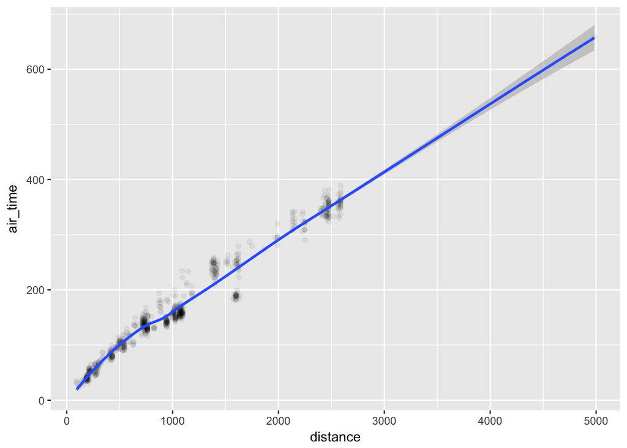

```r
flights %>%
  filter (month == 1, day == 1, !is.na(air_time)) %>%
  ggplot(aes(x = distance, y = air_time)) +
  geom_point(alpha = 0.05)  +
  # alpha is useful for showing overlapping data points.
  geom_smooth()
```

`air_time` and `distance` shows a general linear relationship. But, in comparing air time across carriers, we can do better by accounting for each case of flight destination. Let’s start with a simple apporach through removing the average air time for each destination from the air time variable and comparing the remaining variation across carriers. This is equivalent to fitting a linear regression model with fixed destination-effects and comparing residuals.

```r
idx0 <- flights %>% with(!is.na(air_time))  # TRUE/FALSE vector showing whther air_time is not NA.
## alternatively, one can pass a variable to a custom function
# idx0 <- flights %>% select(air_time) %>% (function(x) !is.na(x))

flights$res <- NA

flights$res[idx0] <- flights %>%
  filter(!is.na(air_time)) %>%
 with(
   lm( air_time ~ as.factor(dest))
        # lm() means  linear model.  y ~ x specifies the formula for regressing y on x.
        # as.factor() converts the string variable "dest" to a class called factor (categorical),
        #  which gets a set of dummy variables in this regression.
   ) %>%
  #  residuals(object_from_lm) retrieves residuals from the regression results of "object_from_lm".
  residuals()

stat_res <- flights %>%
  group_by(carrier) %>%
  summarise(
    mean_res = mean(res, na.rm = TRUE),
    sd_res = sd(res, na.rm = TRUE)
    )

left_join(stat_carrier, stat_res, by="carrier") %>% kable(digit=2)
```

| carrier | n_obs | dep_delay | arr_delay | name | mean_res | sd_res |
| --- | --- | --- | --- | --- | --- | --- |
| UA | 58665 | 12.11 | 3.56 | United Air Lines Inc. | -0.87 | 14.59 |
| B6 | 54635 | 13.02 | 9.46 | JetBlue Airways | 0.28 | 11.55 |
| EV | 54173 | 19.96 | 15.80 | ExpressJet Airlines Inc. | -0.37 | 8.94 |
| DL | 48110 | 9.26 | 1.64 | Delta Air Lines Inc. | -0.20 | 12.32 |
| AA | 32729 | 8.59 | 0.36 | American Airlines Inc. | 0.68 | 13.86 |
| MQ | 26397 | 10.55 | 10.77 | Envoy Air | 0.45 | 8.87 |
| US | 20536 | 3.78 | 2.13 | US Airways Inc. | -0.42 | 9.43 |
| 9E | 18460 | 16.73 | 7.38 | Endeavor Air Inc. | 0.84 | 8.76 |
| WN | 12275 | 17.71 | 9.65 | Southwest Airlines Co. | 0.16 | 12.55 |
| VX | 5162 | 12.87 | 1.76 | Virgin America | 3.26 | 17.58 |
| FL | 3260 | 18.73 | 20.12 | AirTran Airways Corporation | 1.16 | 8.75 |
| AS | 714 | 5.80 | -9.93 | Alaska Airlines Inc. | -2.13 | 16.17 |
| F9 | 685 | 20.22 | 21.92 | Frontier Airlines Inc. | 3.12 | 15.16 |
| YV | 601 | 19.00 | 15.56 | Mesa Airlines Inc. | -0.05 | 7.06 |
| HA | 342 | 4.90 | -6.92 | Hawaiian Airlines Inc. | 5.64 | 20.69 |
| OO | 32 | 12.59 | 11.93 | SkyWest Airlines Inc. | 1.02 | 7.26 |

The differences of means are small compared to standard deviations. Let’s take a case of comparison between the United Airlines and the American Airlines by t-test.

```r
# t-test comparing UA vs AA for the mean air time
flights %>%
  with({
    idx_UA <- carrier == "UA"
    idx_AA <- carrier == "AA"
    t.test(res[idx_UA], res[idx_AA])
    })
```

```
##
##  Welch Two Sample t-test
##
## data:  res[idx_UA] and res[idx_AA]
## t = -15.722, df = 68826, p-value < 2.2e-16
## alternative hypothesis: true difference in means is not equal to 0
## 95 percent confidence interval:
##  -1.741133 -1.355142
## sample estimates:
##  mean of x  mean of y
## -0.8689523  0.6791852
```

This may be surprising, but with a large number of observations, we can detect a small difference in means, statistically speaking.

Let’s do this sort of comparison all at once in a regression. This can be done by using fixed effects for carriers and destinations and comparing the coefficients of carrier fixed effects. Since we used the United Airlines in the previous case, let’s set United Airlines to be a reference of carrier fixed effects. This means that the coefficient of the United is set to zero, and the coefficients of all other airlines capture the differences from the United.

```r
flights$carrier %>% table()
```

```
## .
##    UA    9E    AA    AS    B6    DL    EV    F9    FL    HA    MQ    OO
## 58665 18460 32729   714 54635 48110 54173   685  3260   342 26397    32
##    US    VX    WN    YV
## 20536  5162 12275   601
```

```r
flights$carrier <- relevel(factor(flights$carrier), ref="UA")
  # reference level at the United Airlines
flights$carrier %>% table()
```

```
## .
##    UA    9E    AA    AS    B6    DL    EV    F9    FL    HA    MQ    OO
## 58665 18460 32729   714 54635 48110 54173   685  3260   342 26397    32
##    US    VX    WN    YV
## 20536  5162 12275   601
```

```r
f1 <- flights %>%
 with(
   lm( air_time  ~  as.factor(carrier) + as.factor(dest) )
    # fixed effects for carriers and destinations
 )

# 119 coefficients: 16 carriers + 105 destinations - 2 (reference carrier and reference destination)
tidy(f1)[1:20,]
```

```
##                    term     estimate  std.error    statistic       p.value
## 1           (Intercept)  247.9884874 0.75069658  330.3445016  0.000000e+00
## 2  as.factor(carrier)9E    1.8015498 0.12723996   14.1586788  1.702649e-45
## 3  as.factor(carrier)AA    1.9326712 0.09731105   19.8607572  1.002388e-87
## 4  as.factor(carrier)AS   -1.9071536 0.49596319   -3.8453531  1.204017e-04
## 5  as.factor(carrier)B6    1.1808039 0.08495098   13.8998267  6.535025e-44
## 6  as.factor(carrier)DL    0.7531812 0.08722600    8.6348244  5.907432e-18
## 7  as.factor(carrier)EV    0.4174574 0.11044837    3.7796605  1.570702e-04
## 8  as.factor(carrier)F9    3.8891981 0.48090201    8.0872985  6.120836e-16
## 9  as.factor(carrier)FL    2.6434074 0.27600661    9.5773336  1.002386e-21
## 10 as.factor(carrier)HA   11.0125104 0.89821710   12.2604106  1.503557e-34
## 11 as.factor(carrier)MQ    1.4592669 0.11892133   12.2708590  1.321669e-34
## 12 as.factor(carrier)OO    1.8091432 2.21222472    0.8177936  4.134757e-01
## 13 as.factor(carrier)US    0.1319337 0.13826299    0.9542230  3.399715e-01
## 14 as.factor(carrier)VX    4.5298528 0.18441295   24.5636378 4.086448e-133
## 15 as.factor(carrier)WN    1.2226161 0.17520980    6.9780125  2.999500e-12
## 16 as.factor(carrier)YV    0.5167461 0.52737831    0.9798395  3.271661e-01
## 17   as.factor(dest)ACK -207.1011095 1.04478912 -198.2228803  0.000000e+00
## 18   as.factor(dest)ALB -216.6188634 0.95130943 -227.7059972  0.000000e+00
## 19   as.factor(dest)ANC  165.1365126 4.26930687   38.6799351  0.000000e+00
## 20   as.factor(dest)ATL -136.1282095 0.75641976 -179.9638460  0.000000e+00
```

```r
flights %>%
  with({
    n_carrier <- unique(carrier) %>% length()
    n_dest <- unique(dest) %>% length()
    print(paste('There are', n_carrier, 'distinct carriers and',
                n_dest,'distinct destinations in the data.' ))
  })
```

```
## [1] "There are 16 distinct carriers and 105 distinct destinations in the data."
```

```r
lm_rlt1 <- tidy(f1) %>% filter(grepl("carrier",term))
  # keep only rows with term-column containing "carrier"
lm_rlt1 <- lm_rlt1 %>% mutate(carrier = gsub('as.factor\\(carrier\\)','', term))
  # create column named carrier
lm_rlt1 <- lm_rlt1 %>% select(-term)  # drop column term

stat_carrier_base_UA <- stat_carrier %>%
  mutate(
    dep_delay = dep_delay - dep_delay[carrier=='UA'],
    arr_delay = arr_delay - arr_delay[carrier=='UA']
    )

left_join(stat_carrier_base_UA, lm_rlt1, by="carrier") %>% kable(digit=2)
```

| carrier | n_obs | dep_delay | arr_delay | name | estimate | std.error | statistic | p.value |
| --- | --- | --- | --- | --- | --- | --- | --- | --- |
| UA | 58665 | 0.00 | 0.00 | United Air Lines Inc. | NA | NA | NA | NA |
| B6 | 54635 | 0.92 | 5.90 | JetBlue Airways | 1.18 | 0.08 | 13.90 | 0.00 |
| EV | 54173 | 7.85 | 12.24 | ExpressJet Airlines Inc. | 0.42 | 0.11 | 3.78 | 0.00 |
| DL | 48110 | -2.84 | -1.91 | Delta Air Lines Inc. | 0.75 | 0.09 | 8.63 | 0.00 |
| AA | 32729 | -3.52 | -3.19 | American Airlines Inc. | 1.93 | 0.10 | 19.86 | 0.00 |
| MQ | 26397 | -1.55 | 7.22 | Envoy Air | 1.46 | 0.12 | 12.27 | 0.00 |
| US | 20536 | -8.32 | -1.43 | US Airways Inc. | 0.13 | 0.14 | 0.95 | 0.34 |
| 9E | 18460 | 4.62 | 3.82 | Endeavor Air Inc. | 1.80 | 0.13 | 14.16 | 0.00 |
| WN | 12275 | 5.61 | 6.09 | Southwest Airlines Co. | 1.22 | 0.18 | 6.98 | 0.00 |
| VX | 5162 | 0.76 | -1.79 | Virgin America | 4.53 | 0.18 | 24.56 | 0.00 |
| FL | 3260 | 6.62 | 16.56 | AirTran Airways Corporation | 2.64 | 0.28 | 9.58 | 0.00 |
| AS | 714 | -6.30 | -13.49 | Alaska Airlines Inc. | -1.91 | 0.50 | -3.85 | 0.00 |
| F9 | 685 | 8.11 | 18.36 | Frontier Airlines Inc. | 3.89 | 0.48 | 8.09 | 0.00 |
| YV | 601 | 6.89 | 12.00 | Mesa Airlines Inc. | 0.52 | 0.53 | 0.98 | 0.33 |
| HA | 342 | -7.21 | -10.47 | Hawaiian Airlines Inc. | 11.01 | 0.90 | 12.26 | 0.00 |
| OO | 32 | 0.48 | 8.37 | SkyWest Airlines Inc. | 1.81 | 2.21 | 0.82 | 0.41 |

The “estimate” column shows the mean difference in air time with the United, accounting for flight destination. The estimate tends to be more precise for carriers with larger numbers of observations. We can see the tendency that low-cost carriers like the Virgin America, the Air Tran, and the Frontier Airlines tend to show particularly longer air times than the United. Here the Hawaian Airlines shows a much longer air time. These results differ from the averages delays we calculated previously, and it may be that completely different mechanisms govern delays and air time performances.

Now, let’s take another step to account for flight timing. We can do this by removing the averages of air time for specific date and hour of the flight. We normally would add fixed effects for each date and hour (`time_hour` variable here). However, in this case that would mean adding nearly 7,000 dummy variables to our linear regression, which is computationally too intensive. We can approximate this estimation by subtracting the average air time for each combination of `time_hour` and `dest` from the total variation, so that the variation of `air time` is centered at zero-mean for each combination of `time_hour` and `dest`. Then, we estimate a linear model of this centered variable with destination fixed effects.

```r
## Adding time_hour fixed effects is too computationally intensive
# f1 <- flights %>%
#  with(
#    lm( air_time  ~  as.factor(carrier) + as.factor(dest) + as.factor(time_hour))
#  )

unique(flights$time_hour) %>% length()  # 6,936 unique time_hour
```

```
## [1] 6936
```

```r
flights <- flights %>%
  group_by(dest, time_hour) %>%    # group_by() for the combination of dest and time_hour
  mutate(
    air_time_centered = air_time - mean(air_time, na.rm=TRUE)
  )

f2 <- flights %>%
 with(
   lm( air_time_centered  ~  as.factor(carrier) + as.factor(dest) )
 )

lm_rlt2 <- tidy(f2) %>% filter(grepl("carrier",term))
lm_rlt2 <- lm_rlt2 %>% mutate(carrier = gsub('as.factor\\(carrier\\)','', term))
lm_rlt2 <- lm_rlt2 %>% select(-term)

stat_carrier_base_UA2 <-  stat_carrier_base_UA %>% select(-c(dep_delay, arr_delay))
stat_carrier_rlt2 <- left_join(stat_carrier_base_UA2, lm_rlt2, by="carrier")

stat_carrier_rlt2 %>% kable(digit=2) # Note: standard errors, t-stat, and p-val are incorrect
```

| carrier | n_obs | name | estimate | std.error | statistic | p.value |
| --- | --- | --- | --- | --- | --- | --- |
| UA | 58665 | United Air Lines Inc. | NA | NA | NA | NA |
| B6 | 54635 | JetBlue Airways | 0.82 | 0.03 | 32.24 | 0.00 |
| EV | 54173 | ExpressJet Airlines Inc. | 0.88 | 0.03 | 26.50 | 0.00 |
| DL | 48110 | Delta Air Lines Inc. | 0.52 | 0.03 | 19.85 | 0.00 |
| AA | 32729 | American Airlines Inc. | 1.20 | 0.03 | 41.06 | 0.00 |
| MQ | 26397 | Envoy Air | 1.00 | 0.04 | 27.84 | 0.00 |
| US | 20536 | US Airways Inc. | -0.09 | 0.04 | -2.21 | 0.03 |
| 9E | 18460 | Endeavor Air Inc. | 1.27 | 0.04 | 33.07 | 0.00 |
| WN | 12275 | Southwest Airlines Co. | 1.30 | 0.05 | 24.70 | 0.00 |
| VX | 5162 | Virgin America | 3.47 | 0.06 | 62.59 | 0.00 |
| FL | 3260 | AirTran Airways Corporation | 1.78 | 0.08 | 21.48 | 0.00 |
| AS | 714 | Alaska Airlines Inc. | -2.86 | 0.15 | -19.15 | 0.00 |
| F9 | 685 | Frontier Airlines Inc. | 1.99 | 0.14 | 13.73 | 0.00 |
| YV | 601 | Mesa Airlines Inc. | 0.78 | 0.16 | 4.89 | 0.00 |
| HA | 342 | Hawaiian Airlines Inc. | 1.34 | 0.27 | 4.96 | 0.00 |
| OO | 32 | SkyWest Airlines Inc. | 3.50 | 0.67 | 5.26 | 0.00 |

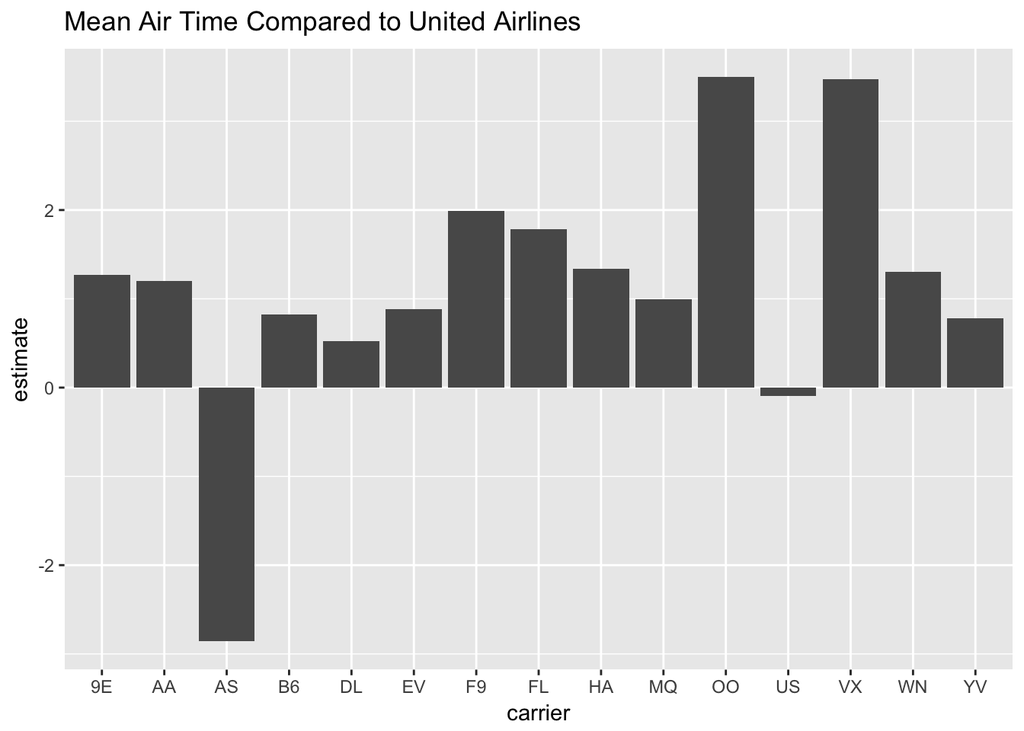

```r
stat_carrier_rlt2 %>% filter(carrier!='UA') %>%
  ggplot(aes(x = carrier, y = estimate)) + geom_col() +
  labs(title = "Mean Air Time Compared to United Airlines")
```

The accuracy of this approach is influenced by the unblanaced data points for the combination of `time_hour` and `dest` since many `time_hour`-`dest` pairs do not have flights offered by all carriers. Nonetheless, the point estimate in the “estimate” column should be *approximately* close to what we would obtain if we regress `air_time` on fixed effects of `carrier`, and `time_hour`, `dest`. Note that the standard errors are not correct in the table because the centered variable has less total variation than the original `air_time` variable. (One can derive correct standard errors, for example, through bootstrapping techniques. Also, please note that formal statistical analyses will be covered in later sections.)

Overall, we see a tendency that low-cost carriers like the Sky West Airlines, the Virgin America, the Frontier Airlines, and the Air Tran show particularly longer air time than the United Airlines, but other low-cost carriers like the Jet Blue Airways and the Southwest Airlines show less obvious differences. The Hawaian Airlines and the Alaskan Airlines may be somewhat different from other carriers perhaps because they are more specialized in particular flight times and destimations compared to other carriers.

Given that the magnitude of the differnces are relatively small (e.g. less than 5 minutes), are these differences in air time important? May be not. But, we may or may not have known that those differences would be small. Is knowing that important? Well, to those who happen to believe that traditional carriers can get them to their destinations faster compared to low-cost carriers, we can point out that the *air time differences* by carrier are pretty small. Is that it (for all that work)? Anything else? Anyone? …

## Reflections

This last point highlights the fact that an interesting data analysis requires asking interesting questions. One needs **the right data**, **the right tools**, and **the right questions**. In short time, increasingly abundant and complex data will become avilable to many people, and the tools of analysis will become even more diverse and sophisticated. For those, we will be able to learn relatively quickly. The most important skill of data analysis is and will be **the ability to ask interesting questions**. That is, the best data mining tool is your mighty mind.

Training your mind to ask interesting questions takes time and practice. To help you get started or sharpen your mind, the tools of `deplyr` and `ggplot` packages provide an easy-to-access language to work with data in R.